# A Git workflow with GitHub Desktop

In this guide, we will work on a cook book project using Git and GitHub Desktop. We will start going through all the steps for an individual project (you’re working on the cook book alone) and then we will see how to collaborate with others.

# Preparations

To follow this guide you need:

- Git installed
- GitHub Desktop installed
- A GitHub account connected to your GitHub Desktop program

Check out the course preparations if you miss anything from this list. There you will find all links and instructions to set everything up.

# A Git workflow for your individual project

## Step 1: Initialize a new repository

Before you start working on the cookbook project, you need to initialize a new Git repository. There are two options to start working with a Git repository:

1. Create a new repository from scratch
2. Use an existing project and put it under version control (if you already have a cook book folder on your computer)

For our cook book, we choose option 1 because we don’t have a project yet.

**Option 1: Start a new project**

Go to **File -> New repository** (keyboard shortcut Ctrl/Cmd + N)

[figure not shown]

This opens up the dialog box below. You can give your repository a name, add a description (optional) and then choose where on your computer it should be created (the local path). If you want, you can also initialize the repo with a README file. This is usually a good idea as you can use this file to guide users through the repository. For the cook book project, my setup looks like this:

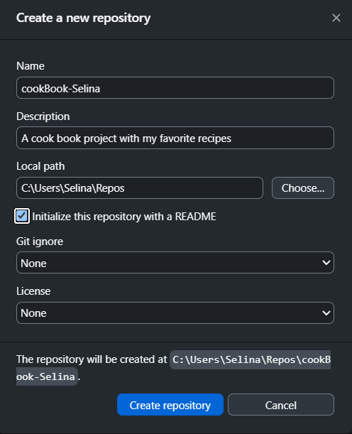

Click **Create repository** when you are done.

**Option 2: Use an existing project**

If you already have a project folder on your computer and you want to use Git to version control it, you can navigate to **File -> Add local repository** (keyboard shortcut Ctrl/Cmd + O)

[figure not shown]

Choose the folder where your project is located and click on **Add repository**.

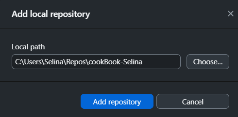

Then, fill out the dialog box just like in option 1 but leave the project name as suggested by GitHub Desktop to match the folder name you already created.

Click on **Create repository** when you are done.

Now you successfully created a new Git repository for your cook book project. To open the folder where the repository is stored, you can go to **Repository -> Show in Explorer** (macOS: **Show in Finder**). This will open your file explorer (Windows Explorer, Finder, …) in the folder of your repository:

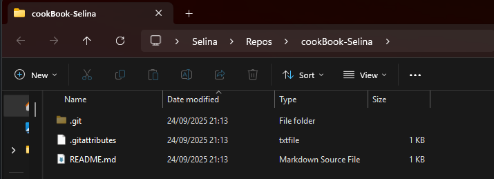

There already is some content in the project folder:

- A `.git` folder that contains all the information about the Git repository (You don’t have to open this folder, but this is where all the Git magic happens). If you don’t see this folder, make sure that your file explorer shows hidden files.
- A `README.md` file because we initialized the repository with a README file
- A `.gitattributes` file that is used to define attributes for certain files (you usually don’t have to change this file)

## Step 2: Add the first recipe

Open your cook book project in the file explorer (**Repository -> Show in Explorer**, on macOS **Show in Finder**).

Add a new text file with your favorite recipe (Let’s assume it’s pie). Create a file called pie.txt and add the recipe text below to it:

```markdown
Ingredients:
150 g butter
200 g sugar
3 eggs
350 g flour
1 pkg. baking powder
juice from one lemon

Mix everything together and put in the oven
for 45 mins at 200 °C.
```

Save the file and switch back to GitHub Desktop.

### Explore the changes

GitHub Desktop records all changes to your project. So it will notice that you added the pie recipe. Have a look at the user interface to see how much information and options you have now:

[figure not shown]

Notice, that by default, GitHub Desktop stages your files (i.e. marks them to be part of the next commit). If you want to remove a file from the staging area, just uncheck the box next to the file.

If you have multiple files that you want to commit separately, then you can uncheck them all and commit them one by one.

## Step 3: Make a commit

By making a commit, you save the current state of your project to the local Git repository. All changes that are staged (i.e. with the check mark next to them checked) will be part of the commit.

To commit the staged changes, you need to enter a short commit message summarizing your changes. GitHub Desktop suggests a default message (here “Create pie.txt”) but usually it’s a good idea to be more specific than this default.

Optionally, you can also add a more detailed description of your changes in the description box below:

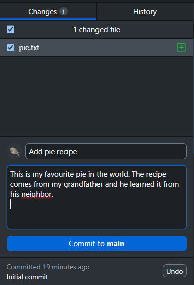

When you are ready click on **Commit to main**.

**TipGood commit messages**

There are guidelines on how to write good commit messages. This becomes especially important when collaborating. Have a look [here](https://cbea.ms/git-commit/) for some guidelines on how to write good commit messages and why this is important.

### Look at the commit history

To look at the history of your commits, you can switch from the “Changes” to the “History” view of GitHub Desktop. It gives you all the details about previous commits:

[figure not shown]

You should see two commits:

- An initial commit that was automatically created when you initialized the repository
- Your commit that added the pie recipe

You can always browse the history to look at previous commits and see what changed in each commit.

## Step 4: Share your project on GitHub

Now we want to share our cook book with the world. GitHub Desktop makes it very easy to publish a repository on GitHub. Just click **Publish repository** on the top right. In the dialogue box, you can choose whether to make your code public (this means everyone can see it) or keep it private (this means only you and invited collaborators can see it).

This is how my cook book repository looks like:

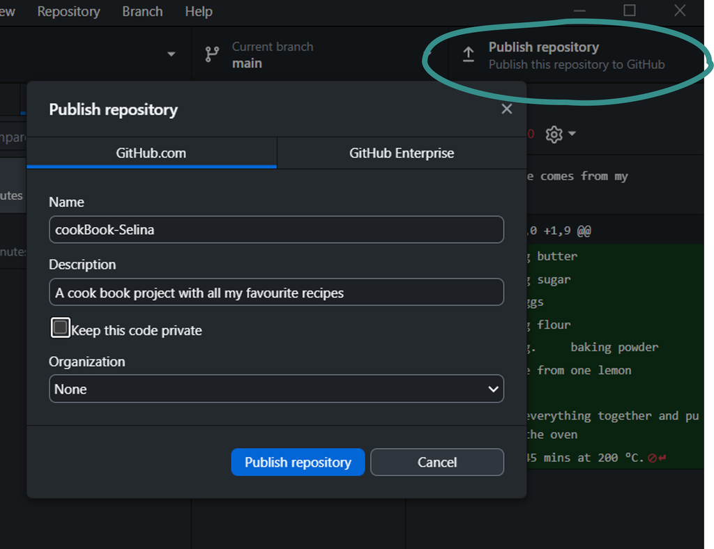

When you are done click **Publish repository**. This will create a new remote repository on GitHub and connect it to your local repository (the one on your computer). GitHub Desktop will also push your existing local commits to GitHub.

You can checkout how your GitHub repository looks like online by going to **Repository -> View on GitHub**.

## Step 5: Push new changes to GitHub

Now we are ready to create more recipes for our cook book and also share them on GitHub.

Just continue to work locally: Add other recipe files, update the existing pie recipe, … Then commit these new changes to the repository (see previous steps). When you are ready to share the new changes on GitHub, you need to push them. Just click one of the two **Push** buttons to update the GitHub repository with the latest local changes.

The small number on the right side of the button indicates how many commits you are about to push (in my case 1).

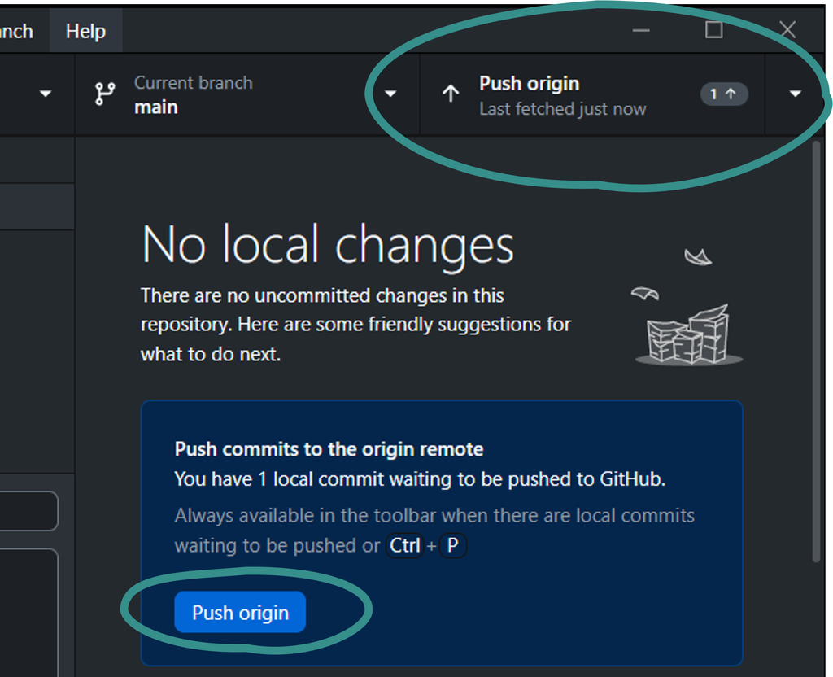

And that’s it! You successfully created a Git workflow for your cook book project. You can now continue to add recipes, commit them and push them to GitHub. If your project is public, you can share it with others just by sharing the link to your GitHub repository.

# Collaboration workflows

Git and GitHub are perfect for collaboration. Let’s assume your friend also has a cook book project on GitHub and you want to help work on their cook book.

If you want to test this workflow by collaborating with yourself, you can just skip step 1 and do the other steps with your own instead of your friend’s cook book.

## Add collaborators to GitHub repository

To collaborate, your friend needs to add you to their GitHub project. On the GitHub webpage of the repository, they can go to **Settings -> Collaborators -> Add people**:

[figure not shown]

Then add people using their GitHub user name. The invited person will get an invitation email for the repository. Accept this invitation and you are now a collaborator on your friend’s project.

## Step 1: Clone a remote repository

Before you can start working on your friend’s cook book, you need to clone their repository. This means getting your own local copy of the cook book.

There are two ways to clone a remote repository in GitHub Desktop:

1. Search for the repository in your list of repositories (only works for GitHub repositories you have access to)
2. Clone any repository using the URL (works for GitHub and other repositories, e.g. Gitlab)

We can use option 1 as your friend already added you as a collaborator to their GitHub repository.

**Option 1: Shared GitHub repository**

As soon as you accepted the invitation to be a collaborator on a GitHub repository, this repository will be listed by GitHub Desktop in the list of your repositories.

To clone a repository you just need to go to **File -> Clone repository**. In the dialogue box that opens stay in the “GitHub.com” tab. There you can scroll through the list of all repositories you have access to and select the one you want to clone.

Select the repository of your friend and choose a path where to store the local copy of the repository:

[figure not shown]

Then click **Clone**.

Now you can start working with the repository of your friend. You could just make changes, commit them and push them to the remote repository (see steps 2-5 in the previous section). But there is a more elegant way that we will see in the next steps.

(Look at option 2 if your friend’s repository is not in the list of your repositories)

**Option 2: Clone repositories using URL**

This option works for GitHub repositories but also for all other remote repositories (e.g. Gitlab).

To clone a repository, you need to know the repositories address. You can find the HTTPS address by clicking the green code button on the repository page on GitHub:

[figure not shown]

Copy the address to your clipboard.

Go to GitHub Desktop and **File -> Clone repository**. In the dialogue box that opens, switch to the URL Tab and paste the URL. Then, you choose a local path for the repository.

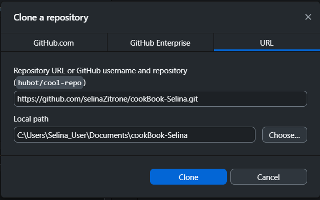

When you are ready click on **Clone**.

Now you can start working with the repository of your friend.

## Step 2: Create a new branch

Let’s say, you want to add a vegan pie recipe to your friend’s cook book. To use the collaboration workflow discussed in the lecture, you need to create a new branch to work on.

In GitHub Desktop, go to **Branch -> New Branch**. Give the branch a short but meaningful name and then click on **Create branch**:

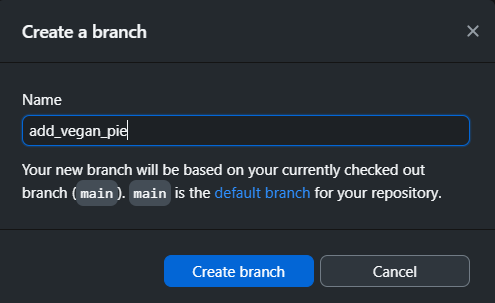

GitHub Desktop will automatically switch to this branch for you. You can see your current branch and switch between branches on the top:

[figure not shown]

Now you can start working on this branch. Add a file for the vegan pie and then commit them like you are used to (see steps 2-3 in the previous section).

## Step 3: Publish and push your branch

To share your branch with the vegan pie recipe with your friend, you need to push the branch to the remote repository on GitHub. This works just like with the main branch. On the top right, just click the **Push** button (The first time, this button will say **Publish branch** instead of Push).

Now your branch should be pushed to GitHub and you can do a pull request.

## Step 4: Create a pull request

See here for a guide on how to create a pull request to ask your friend to integrate your recipe into their cookbook.

# Other things to try

## Revert a commit

If you want to undo a commit without deleting the whole commit history, you can revert the respective commit. Just go to the history tab in GitHub Desktop and find the commit you want to revert. Right-click on the commit and select **Revert changes in commit**:

[figure not shown]

GitHub Desktop will create a new commit that reverts the original commit (in this case deleting the pie recipe that was added in the original commit):

[figure not shown]

This commit can be pushed just like any other commit. This is a safe way to undo changes.

## Ignore files

If you have files in your project that you don’t want to track with Git (e.g. temporary files, large files, …), you can add them to a `.gitignore` file.

Let’s say, I have a word document with my notes in the project and I don’t want to track it with Git and share them on GitHub. So, I don’t want to commit the changes, but instead ignore them.

In GitHub Desktop, you can ignore files that appear in your list of changes by right-clicking on them and selecting **Ignore file**:

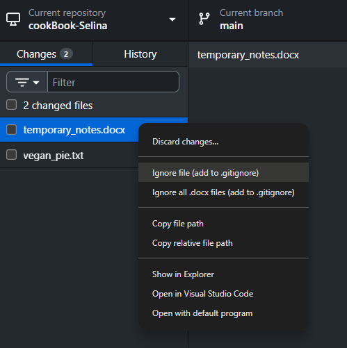

You can also choose to ignore all files of this filetype by selecting **Ignore all files**.

This will automatically create a `.gitignore` file in your project folder (if it doesn’t exist yet) and add the respective file or file type to it.

You can now commit and push the `.gitignore` file to GitHub like any other file:

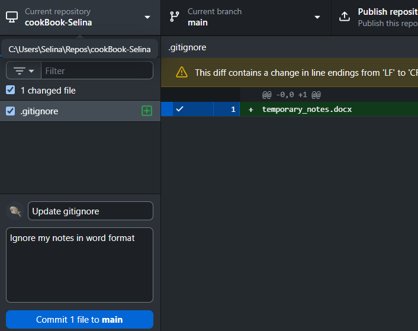

In the future, Git will ignore all files that are listed in the `.gitignore` file and will not show them in the list of changes anymore.

**TipWhat if the file was already committed?**

`.gitignore` only works for files that Git doesn’t track yet. If you already committed a file and then add it to `.gitignore`, Git keeps tracking it.

To stop tracking the file but keep it on your computer:

1. Open the `.gitignore` file in a text editor and add the file name in a new line.
2. Open a terminal in your project (GitHub Desktop: **Repository -> Open in Command Prompt** / **Open in Terminal**) and run:

   ```bash
   git rm --cached my_notes.docx
   ```

   For a whole folder, use `git rm -r --cached folder_name/`.
3. Back in GitHub Desktop, you will see the file listed as **deleted**. Don’t worry: The file is still on your computer. It’s only removed from the repository. Commit this change together with the `.gitignore`.

Keep in mind:

- Old commits still contain the file. To remove it from the history as well, see the box below.
- When your collaborators pull this commit, the file will be deleted from their project folder.

**WarningRemove a file from the history completely**

Sometimes removing a file from the current version is not enough, and you also need to delete it from the history.

Only do this if you accidentally committed secrets (e.g. passwords, which you should also change) or very large data files that slow down your repository. In most other cases, the safer option from the box above is better.

**Not pushed yet?** If the file is only in your last commit, you can undo that commit. In the **History** tab, right-click the commit and select **Undo commit**. Then, in the **Changes** tab, right-click the file, select **Ignore file**, and commit again.

**Already pushed?** Then you need to rewrite the history of your repository. Do this with care, especially if you work with others, and make a backup copy of your project folder first.

1. Install [git filter-repo](https://github.com/newren/git-filter-repo) (e.g. `pip install git-filter-repo`).
2. Clone your repository again into a new folder. In the terminal inside this new folder, run:

   ```bash
   git filter-repo --invert-paths --path my_notes.docx
   ```

   This removes `my_notes.docx` from every commit.
3. For safety, `git filter-repo` removes the connection to GitHub. Add it again and force-push the new history:

   ```bash
   git remote add origin https://github.com/<user>/<repo>.git
   git push origin --force --all
   ```

4. From now on, only work in the new folder. Ask your collaborators to delete their copy and clone the repository again. Otherwise, the old history (including the file) can end up on GitHub again.

For more details, see GitHub’s guide on [removing sensitive data from a repository](https://docs.github.com/en/authentication/keeping-your-account-and-data-secure/removing-sensitive-data-from-a-repository).

## Resolve merge conflicts

A merge conflict happens when the same lines of the same file were changed in two different ways, e.g. on two branches that you want to merge, or locally and on GitHub when you pull. Git cannot decide which version to keep, so it asks you. Don’t worry, nothing is lost.

Let’s say, on `main` I changed `1 tbsp sugar` to `1 tbsp honey` in my banana pancakes recipe. On the branch `more-sugar`, I changed the same line to `3 tbsp sugar`.

When I try to merge `more-sugar` into `main` (**Branch -> Merge into current branch**), GitHub Desktop already warns me that there will be a conflict:

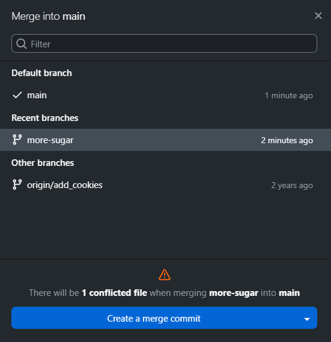

When I click **Create a merge commit**, GitHub Desktop shows me which files have conflicts:

[figure not shown]

Now I have two options:

- Use the dropdown to keep the whole file from one of the branches.
- Open the file in an editor and decide line by line.

In the file, Git marks the conflicting lines like this:

```markdown
<<<<<<< HEAD
1 tbsp honey
=======
3 tbsp sugar
>>>>>>> more-sugar
```

The part between `<<<<<<< HEAD` and `=======` is the version on your current branch (`main`), the part between `=======` and `>>>>>>> more-sugar` is the version from the branch you merge. Keep the version you want (or combine both), delete the marker lines and save the file.

Many editors help you with this. VS Code for example lets you choose a version with one click:

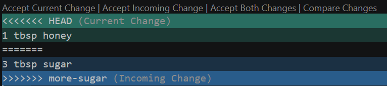

When you switch back to GitHub Desktop, it shows that all conflicts are resolved. Click **Continue merge** to finish the merge with a merge commit:

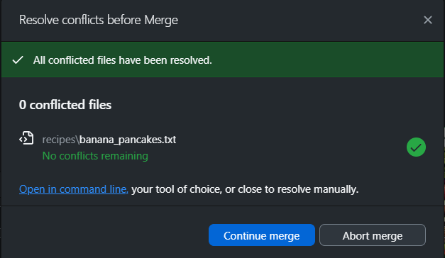

If you change your mind, you can click **Abort merge** at any time to go back to the state before the merge.

**TipAvoid conflicts**

- Pull before you start working
- Commit and push often (small changes)
- Keep branches short-lived and merge them regularly
- Talk to your collaborators about who works on which file